# 2. Uber Driver Data Set

## Data Manipulation

Encoding categorical data or we can say converting categorical data to numerical data using One-Hot encoding

```python
pd.get_dummies(uber_df["PURPOSE*"])
```

|  | Airport/Travel | Between Offices | Charity ($) | Commute | Customer Visit | Errand/Supplies | Meal/Entertain | Meeting | Moving | Temporary Site |
| --- | --- | --- | --- | --- | --- | --- | --- | --- | --- | --- |
| 0 | False | False | False | False | False | False | True | False | False | False |
| 1 | False | False | False | False | False | False | False | False | False | False |
| 2 | False | False | False | False | False | True | False | False | False | False |
| 3 | False | False | False | False | False | False | False | True | False | False |
| 4 | False | False | False | False | True | False | False | False | False | False |
| ... | ... | ... | ... | ... | ... | ... | ... | ... | ... | ... |
| 1149 | False | False | False | False | True | False | False | False | False | False |
| 1150 | False | False | False | False | False | False | False | True | False | False |
| 1151 | False | False | False | False | False | False | False | False | False | True |
| 1152 | False | False | False | False | False | False | False | True | False | False |
| 1153 | False | False | False | False | False | False | False | False | False | True |

1154 rows × 10 columns

```python
uber_df
```

|  | START_DATE* | END_DATE* | CATEGORY* | START* | STOP* | MILES* | PURPOSE* |
| --- | --- | --- | --- | --- | --- | --- | --- |
| 0 | 1/1/2016 21:11 | 1/1/2016 21:17 | Business | Fort Pierce | Fort Pierce | 5.1 | Meal/Entertain |
| 1 | 1/2/2016 1:25 | 1/2/2016 1:37 | Business | Fort Pierce | Fort Pierce | 5.0 | NaN |
| 2 | 1/2/2016 20:25 | 1/2/2016 20:38 | Business | Fort Pierce | Fort Pierce | 4.8 | Errand/Supplies |
| 3 | 1/5/2016 17:31 | 1/5/2016 17:45 | Business | Fort Pierce | Fort Pierce | 4.7 | Meeting |
| 4 | 1/6/2016 14:42 | 1/6/2016 15:49 | Business | Fort Pierce | West Palm Beach | 63.7 | Customer Visit |
| ... | ... | ... | ... | ... | ... | ... | ... |
| 1149 | 12/30/2016 23:06 | 12/30/2016 23:10 | Business | Kar?chi | Kar?chi | 0.8 | Customer Visit |
| 1150 | 12/31/2016 1:07 | 12/31/2016 1:14 | Business | Kar?chi | Kar?chi | 0.7 | Meeting |
| 1151 | 12/31/2016 13:24 | 12/31/2016 13:42 | Business | Kar?chi | Unknown Location | 3.9 | Temporary Site |
| 1152 | 12/31/2016 15:03 | 12/31/2016 15:38 | Business | Unknown Location | Unknown Location | 16.2 | Meeting |
| 1153 | 12/31/2016 21:32 | 12/31/2016 21:50 | Business | Katunayake | Gampaha | 6.4 | Temporary Site |

1154 rows × 7 columns

```python
uber_df["START_DATE*"] = pd.to_datetime(uber_df["START_DATE*"])
```

```python
uber_df["END_DATE*"] = pd.to_datetime(uber_df["END_DATE*"])
```

```python
uber_df.info()
```

```
<class 'pandas.core.frame.DataFrame'>
RangeIndex: 1154 entries, 0 to 1153
Data columns (total 7 columns):
 #   Column       Non-Null Count  Dtype
---  ------       --------------  -----
 0   START_DATE*  1154 non-null   datetime64[ns]
 1   END_DATE*    1154 non-null   datetime64[ns]
 2   CATEGORY*    1154 non-null   object
 3   START*       1154 non-null   object
 4   STOP*        1154 non-null   object
 5   MILES*       1154 non-null   float64
 6   PURPOSE*     652 non-null    object
dtypes: datetime64[ns](2), float64(1), object(4)
memory usage: 63.2+ KB
```

```python
pd.get_dummies(uber_df)
```

|  | START_DATE* | END_DATE* | MILES* | CATEGORY*_Business | CATEGORY*_Personal | START*_Agnew | START*_Almond | START*_Apex | START*_Arabi | START*_Arlington | ... | PURPOSE*_Airport/Travel | PURPOSE*_Between Offices | PURPOSE*_Charity ($) | PURPOSE*_Commute | PURPOSE*_Customer Visit | PURPOSE*_Errand/Supplies | PURPOSE*_Meal/Entertain | PURPOSE*_Meeting | PURPOSE*_Moving | PURPOSE*_Temporary Site |
| --- | --- | --- | --- | --- | --- | --- | --- | --- | --- | --- | --- | --- | --- | --- | --- | --- | --- | --- | --- | --- | --- |
| 0 | 2016-01-01 21:11:00 | 2016-01-01 21:17:00 | 5.1 | True | False | False | False | False | False | False | ... | False | False | False | False | False | False | True | False | False | False |
| 1 | 2016-01-02 01:25:00 | 2016-01-02 01:37:00 | 5.0 | True | False | False | False | False | False | False | ... | False | False | False | False | False | False | False | False | False | False |
| 2 | 2016-01-02 20:25:00 | 2016-01-02 20:38:00 | 4.8 | True | False | False | False | False | False | False | ... | False | False | False | False | False | True | False | False | False | False |
| 3 | 2016-01-05 17:31:00 | 2016-01-05 17:45:00 | 4.7 | True | False | False | False | False | False | False | ... | False | False | False | False | False | False | False | True | False | False |
| 4 | 2016-01-06 14:42:00 | 2016-01-06 15:49:00 | 63.7 | True | False | False | False | False | False | False | ... | False | False | False | False | True | False | False | False | False | False |
| ... | ... | ... | ... | ... | ... | ... | ... | ... | ... | ... | ... | ... | ... | ... | ... | ... | ... | ... | ... | ... | ... |
| 1149 | 2016-12-30 23:06:00 | 2016-12-30 23:10:00 | 0.8 | True | False | False | False | False | False | False | ... | False | False | False | False | True | False | False | False | False | False |
| 1150 | 2016-12-31 01:07:00 | 2016-12-31 01:14:00 | 0.7 | True | False | False | False | False | False | False | ... | False | False | False | False | False | False | False | True | False | False |
| 1151 | 2016-12-31 13:24:00 | 2016-12-31 13:42:00 | 3.9 | True | False | False | False | False | False | False | ... | False | False | False | False | False | False | False | False | False | True |
| 1152 | 2016-12-31 15:03:00 | 2016-12-31 15:38:00 | 16.2 | True | False | False | False | False | False | False | ... | False | False | False | False | False | False | False | True | False | False |
| 1153 | 2016-12-31 21:32:00 | 2016-12-31 21:50:00 | 6.4 | True | False | False | False | False | False | False | ... | False | False | False | False | False | False | False | False | False | True |

1154 rows × 378 columns

```python
pd.get_dummies(uber_df, columns=["CATEGORY*", "PURPOSE*"])
```

|  | START_DATE* | END_DATE* | START* | STOP* | MILES* | CATEGORY*_Business | CATEGORY*_Personal | PURPOSE*_Airport/Travel | PURPOSE*_Between Offices | PURPOSE*_Charity ($) | PURPOSE*_Commute | PURPOSE*_Customer Visit | PURPOSE*_Errand/Supplies | PURPOSE*_Meal/Entertain | PURPOSE*_Meeting | PURPOSE*_Moving | PURPOSE*_Temporary Site |
| --- | --- | --- | --- | --- | --- | --- | --- | --- | --- | --- | --- | --- | --- | --- | --- | --- | --- |
| 0 | 2016-01-01 21:11:00 | 2016-01-01 21:17:00 | Fort Pierce | Fort Pierce | 5.1 | True | False | False | False | False | False | False | False | True | False | False | False |
| 1 | 2016-01-02 01:25:00 | 2016-01-02 01:37:00 | Fort Pierce | Fort Pierce | 5.0 | True | False | False | False | False | False | False | False | False | False | False | False |
| 2 | 2016-01-02 20:25:00 | 2016-01-02 20:38:00 | Fort Pierce | Fort Pierce | 4.8 | True | False | False | False | False | False | False | True | False | False | False | False |
| 3 | 2016-01-05 17:31:00 | 2016-01-05 17:45:00 | Fort Pierce | Fort Pierce | 4.7 | True | False | False | False | False | False | False | False | False | True | False | False |
| 4 | 2016-01-06 14:42:00 | 2016-01-06 15:49:00 | Fort Pierce | West Palm Beach | 63.7 | True | False | False | False | False | False | True | False | False | False | False | False |
| ... | ... | ... | ... | ... | ... | ... | ... | ... | ... | ... | ... | ... | ... | ... | ... | ... | ... |
| 1149 | 2016-12-30 23:06:00 | 2016-12-30 23:10:00 | Kar?chi | Kar?chi | 0.8 | True | False | False | False | False | False | True | False | False | False | False | False |
| 1150 | 2016-12-31 01:07:00 | 2016-12-31 01:14:00 | Kar?chi | Kar?chi | 0.7 | True | False | False | False | False | False | False | False | False | True | False | False |
| 1151 | 2016-12-31 13:24:00 | 2016-12-31 13:42:00 | Kar?chi | Unknown Location | 3.9 | True | False | False | False | False | False | False | False | False | False | False | True |
| 1152 | 2016-12-31 15:03:00 | 2016-12-31 15:38:00 | Unknown Location | Unknown Location | 16.2 | True | False | False | False | False | False | False | False | False | True | False | False |
| 1153 | 2016-12-31 21:32:00 | 2016-12-31 21:50:00 | Katunayake | Gampaha | 6.4 | True | False | False | False | False | False | False | False | False | False | False | True |

1154 rows × 17 columns

### Selection using loc and iloc

```python
uber_df[["MILES*", "PURPOSE*"]]
```

|  | MILES* | PURPOSE* |
| --- | --- | --- |
| 0 | 5.1 | Meal/Entertain |
| 1 | 5.0 | NaN |
| 2 | 4.8 | Errand/Supplies |
| 3 | 4.7 | Meeting |
| 4 | 63.7 | Customer Visit |
| ... | ... | ... |
| 1149 | 0.8 | Customer Visit |
| 1150 | 0.7 | Meeting |
| 1151 | 3.9 | Temporary Site |
| 1152 | 16.2 | Meeting |
| 1153 | 6.4 | Temporary Site |

1154 rows × 2 columns

```python
uber_df.loc[:,["MILES*", "PURPOSE*"]]
```

|  | MILES* | PURPOSE* |
| --- | --- | --- |
| 0 | 5.1 | Meal/Entertain |
| 1 | 5.0 | NaN |
| 2 | 4.8 | Errand/Supplies |
| 3 | 4.7 | Meeting |
| 4 | 63.7 | Customer Visit |
| ... | ... | ... |
| 1149 | 0.8 | Customer Visit |
| 1150 | 0.7 | Meeting |
| 1151 | 3.9 | Temporary Site |
| 1152 | 16.2 | Meeting |
| 1153 | 6.4 | Temporary Site |

1154 rows × 2 columns

```python
uber_df.iloc[:,[2,5,6]]
```

|  | CATEGORY* | MILES* | PURPOSE* |
| --- | --- | --- | --- |
| 0 | Business | 5.1 | Meal/Entertain |
| 1 | Business | 5.0 | NaN |
| 2 | Business | 4.8 | Errand/Supplies |
| 3 | Business | 4.7 | Meeting |
| 4 | Business | 63.7 | Customer Visit |
| ... | ... | ... | ... |
| 1149 | Business | 0.8 | Customer Visit |
| 1150 | Business | 0.7 | Meeting |
| 1151 | Business | 3.9 | Temporary Site |
| 1152 | Business | 16.2 | Meeting |
| 1153 | Business | 6.4 | Temporary Site |

1154 rows × 3 columns

```python
uber_df.iloc[0,1]
```

```
Timestamp('2016-01-01 21:17:00')
```

```python
# If we want to select the records from 1 to 12 of START_DATE*, CATEGORY*, START* and MILES* columns using loc selection method
uber_df.loc[1:12, ["START_DATE*", "CATEGORY*", "START*", "MILES*"]]
```

|  | START_DATE* | CATEGORY* | START* | MILES* |
| --- | --- | --- | --- | --- |
| 1 | 2016-01-02 01:25:00 | Business | Fort Pierce | 5.0 |
| 2 | 2016-01-02 20:25:00 | Business | Fort Pierce | 4.8 |
| 3 | 2016-01-05 17:31:00 | Business | Fort Pierce | 4.7 |
| 4 | 2016-01-06 14:42:00 | Business | Fort Pierce | 63.7 |
| 5 | 2016-01-06 17:15:00 | Business | West Palm Beach | 4.3 |
| 6 | 2016-01-06 17:30:00 | Business | West Palm Beach | 7.1 |
| 7 | 2016-01-07 13:27:00 | Business | Cary | 0.8 |
| 8 | 2016-01-10 08:05:00 | Business | Cary | 8.3 |
| 9 | 2016-01-10 12:17:00 | Business | Jamaica | 16.5 |
| 10 | 2016-01-10 15:08:00 | Business | New York | 10.8 |
| 11 | 2016-01-10 18:18:00 | Business | Elmhurst | 7.5 |
| 12 | 2016-01-10 19:12:00 | Business | Midtown | 6.2 |

```python
# If we want to select the records from 1 to 12 of START_DATE*, CATEGORY*, START* and MILES* columns using iloc selection method
uber_df.iloc[1:13, [0,2,3,5]]
```

|  | START_DATE* | CATEGORY* | START* | MILES* |
| --- | --- | --- | --- | --- |
| 1 | 2016-01-02 01:25:00 | Business | Fort Pierce | 5.0 |
| 2 | 2016-01-02 20:25:00 | Business | Fort Pierce | 4.8 |
| 3 | 2016-01-05 17:31:00 | Business | Fort Pierce | 4.7 |
| 4 | 2016-01-06 14:42:00 | Business | Fort Pierce | 63.7 |
| 5 | 2016-01-06 17:15:00 | Business | West Palm Beach | 4.3 |
| 6 | 2016-01-06 17:30:00 | Business | West Palm Beach | 7.1 |
| 7 | 2016-01-07 13:27:00 | Business | Cary | 0.8 |
| 8 | 2016-01-10 08:05:00 | Business | Cary | 8.3 |
| 9 | 2016-01-10 12:17:00 | Business | Jamaica | 16.5 |
| 10 | 2016-01-10 15:08:00 | Business | New York | 10.8 |
| 11 | 2016-01-10 18:18:00 | Business | Elmhurst | 7.5 |
| 12 | 2016-01-10 19:12:00 | Business | Midtown | 6.2 |

### Filtering or Conditional Selection

In pandas, when you apply conditional selection to a DataFrame, you specify the condition at the row level because you are interested in selecting specific rows that satisfy a particular condition. This allows you to filter and extract the rows of interest based on your criteria.

```python
# To figure out the rides where the total miles was less than 10, we will have to apply a condition on the miles column
uber_df["MILES*"]<10
```

```
0        True
1        True
2        True
3        True
4       False
        ...
1149     True
1150     True
1151     True
1152    False
1153     True
Name: MILES*, Length: 1154, dtype: bool
```

```python
uber_df[uber_df["MILES*"]<10]
```

|  | START_DATE* | END_DATE* | CATEGORY* | START* | STOP* | MILES* | PURPOSE* |
| --- | --- | --- | --- | --- | --- | --- | --- |
| 0 | 2016-01-01 21:11:00 | 2016-01-01 21:17:00 | Business | Fort Pierce | Fort Pierce | 5.1 | Meal/Entertain |
| 1 | 2016-01-02 01:25:00 | 2016-01-02 01:37:00 | Business | Fort Pierce | Fort Pierce | 5.0 | NaN |
| 2 | 2016-01-02 20:25:00 | 2016-01-02 20:38:00 | Business | Fort Pierce | Fort Pierce | 4.8 | Errand/Supplies |
| 3 | 2016-01-05 17:31:00 | 2016-01-05 17:45:00 | Business | Fort Pierce | Fort Pierce | 4.7 | Meeting |
| 5 | 2016-01-06 17:15:00 | 2016-01-06 17:19:00 | Business | West Palm Beach | West Palm Beach | 4.3 | Meal/Entertain |
| ... | ... | ... | ... | ... | ... | ... | ... |
| 1148 | 2016-12-30 16:45:00 | 2016-12-30 17:08:00 | Business | Kar?chi | Kar?chi | 4.6 | Meeting |
| 1149 | 2016-12-30 23:06:00 | 2016-12-30 23:10:00 | Business | Kar?chi | Kar?chi | 0.8 | Customer Visit |
| 1150 | 2016-12-31 01:07:00 | 2016-12-31 01:14:00 | Business | Kar?chi | Kar?chi | 0.7 | Meeting |
| 1151 | 2016-12-31 13:24:00 | 2016-12-31 13:42:00 | Business | Kar?chi | Unknown Location | 3.9 | Temporary Site |
| 1153 | 2016-12-31 21:32:00 | 2016-12-31 21:50:00 | Business | Katunayake | Gampaha | 6.4 | Temporary Site |

837 rows × 7 columns

```python
miles_cond = uber_df["MILES*"]<10
```

```python
uber_df.loc[miles_cond, ["CATEGORY*","MILES*","PURPOSE*"]]
```

|  | CATEGORY* | MILES* | PURPOSE* |
| --- | --- | --- | --- |
| 0 | Business | 5.1 | Meal/Entertain |
| 1 | Business | 5.0 | NaN |
| 2 | Business | 4.8 | Errand/Supplies |
| 3 | Business | 4.7 | Meeting |
| 5 | Business | 4.3 | Meal/Entertain |
| ... | ... | ... | ... |
| 1148 | Business | 4.6 | Meeting |
| 1149 | Business | 0.8 | Customer Visit |
| 1150 | Business | 0.7 | Meeting |
| 1151 | Business | 3.9 | Temporary Site |
| 1153 | Business | 6.4 | Temporary Site |

837 rows × 3 columns

```python
# Find out all the miles of the first 20 rides that had started from Cary
uber_df.loc[uber_df["START*"]=="Cary", ["MILES*"]].head(n=20)
```

|  | MILES* |
| --- | --- |
| 7 | 0.8 |
| 8 | 8.3 |
| 28 | 10.4 |
| 30 | 4.8 |
| 34 | 17.1 |
| 37 | 1.6 |
| 38 | 2.4 |
| 39 | 1.0 |
| 43 | 1.4 |
| 44 | 0.5 |
| 45 | 1.8 |
| 46 | 18.7 |
| 50 | 19.0 |
| 53 | 4.6 |
| 54 | 5.2 |
| 55 | 10.4 |
| 57 | 5.8 |
| 59 | 5.7 |
| 61 | 19.4 |
| 65 | 6.0 |

### Sorting

```python
uber_df.columns
```

```
Index(['START_DATE*', 'END_DATE*', 'CATEGORY*', 'START*', 'STOP*', 'MILES*',
       'PURPOSE*'],
      dtype='object')
```

```python
# This method sorts the values in ascending order only
uber_df.sort_values(by=["MILES*"]).head(n=10)
```

|  | START_DATE* | END_DATE* | CATEGORY* | START* | STOP* | MILES* | PURPOSE* |
| --- | --- | --- | --- | --- | --- | --- | --- |
| 420 | 2016-06-08 17:16:00 | 2016-06-08 17:18:00 | Business | Soho | Tribeca | 0.5 | Errand/Supplies |
| 44 | 2016-01-26 17:27:00 | 2016-01-26 17:29:00 | Business | Cary | Cary | 0.5 | Errand/Supplies |
| 120 | 2016-02-17 16:38:00 | 2016-02-17 16:43:00 | Business | Katunayaka | Katunayaka | 0.5 | Errand/Supplies |
| 1111 | 2016-12-25 00:10:00 | 2016-12-25 00:14:00 | Business | Lahore | Lahore | 0.6 | Errand/Supplies |
| 516 | 2016-07-05 16:48:00 | 2016-07-05 16:52:00 | Business | Whitebridge | Whitebridge | 0.6 | Errand/Supplies |
| 1121 | 2016-12-27 12:53:00 | 2016-12-27 12:57:00 | Business | Kar?chi | Kar?chi | 0.6 | Meal/Entertain |
| 1110 | 2016-12-24 22:04:00 | 2016-12-24 22:09:00 | Business | Lahore | Lahore | 0.6 | Errand/Supplies |
| 945 | 2016-11-12 13:46:00 | 2016-11-12 13:50:00 | Business | Central | West Berkeley | 0.6 | NaN |
| 925 | 2016-11-09 18:09:00 | 2016-11-09 18:14:00 | Business | Sunnyside | Ingleside | 0.7 | NaN |
| 759 | 2016-09-14 11:55:00 | 2016-09-14 11:59:00 | Business | Unknown Location | Unknown Location | 0.7 | NaN |

```python
uber_df.sort_values(by=["MILES*"], ascending=False).head(n=10)
```

|  | START_DATE* | END_DATE* | CATEGORY* | START* | STOP* | MILES* | PURPOSE* |
| --- | --- | --- | --- | --- | --- | --- | --- |
| 269 | 2016-03-25 16:52:00 | 2016-03-25 22:22:00 | Business | Latta | Jacksonville | 310.3 | Customer Visit |
| 270 | 2016-03-25 22:54:00 | 2016-03-26 01:39:00 | Business | Jacksonville | Kissimmee | 201.0 | Meeting |
| 881 | 2016-10-30 15:22:00 | 2016-10-30 18:23:00 | Business | Asheville | Mebane | 195.9 | NaN |
| 776 | 2016-09-27 21:01:00 | 2016-09-28 02:37:00 | Business | Unknown Location | Unknown Location | 195.6 | NaN |
| 546 | 2016-07-14 16:39:00 | 2016-07-14 20:05:00 | Business | Morrisville | Banner Elk | 195.3 | NaN |
| 559 | 2016-07-17 12:20:00 | 2016-07-17 15:25:00 | Personal | Boone | Cary | 180.2 | Commute |
| 297 | 2016-04-02 19:38:00 | 2016-04-02 22:36:00 | Business | Jacksonville | Ridgeland | 174.2 | Customer Visit |
| 299 | 2016-04-03 02:00:00 | 2016-04-03 04:16:00 | Business | Florence | Cary | 159.3 | Meeting |
| 727 | 2016-08-27 16:15:00 | 2016-08-27 19:13:00 | Business | Unknown Location | Unknown Location | 156.9 | NaN |
| 268 | 2016-03-25 13:24:00 | 2016-03-25 16:22:00 | Business | Cary | Latta | 144.0 | Customer Visit |

```python
uber_df.sort_values(by=["START*", "MILES*"], ascending=[True, False]).head(n=10)
```

|  | START_DATE* | END_DATE* | CATEGORY* | START* | STOP* | MILES* | PURPOSE* |
| --- | --- | --- | --- | --- | --- | --- | --- |
| 906 | 2016-11-04 21:04:00 | 2016-11-04 21:20:00 | Business | Agnew | Cory | 4.3 | NaN |
| 911 | 2016-11-06 10:50:00 | 2016-11-06 11:04:00 | Business | Agnew | Renaissance | 2.4 | NaN |
| 908 | 2016-11-05 08:34:00 | 2016-11-05 08:43:00 | Business | Agnew | Renaissance | 2.2 | NaN |
| 910 | 2016-11-05 19:20:00 | 2016-11-05 19:28:00 | Business | Agnew | Agnew | 2.2 | NaN |
| 879 | 2016-10-30 12:58:00 | 2016-10-30 13:18:00 | Business | Almond | Bryson City | 15.2 | NaN |
| 1001 | 2016-11-26 17:36:00 | 2016-11-26 17:56:00 | Business | Apex | Holly Springs | 9.0 | Meeting |
| 1033 | 2016-12-09 13:15:00 | 2016-12-09 13:43:00 | Business | Apex | Cary | 8.8 | Temporary Site |
| 410 | 2016-06-06 21:08:00 | 2016-06-06 21:37:00 | Business | Apex | Cary | 7.2 | Meal/Entertain |
| 647 | 2016-08-10 19:47:00 | 2016-08-10 20:02:00 | Business | Apex | Cary | 6.0 | NaN |
| 60 | 2016-01-30 18:09:00 | 2016-01-30 18:24:00 | Business | Apex | Cary | 5.7 | Customer Visit |

We are looking forward to create a new column called "Trip Type" which holds the values - Long trip, Short trip according to the number of miles cover

```python
import numpy as np
```

In the np.where method:

- The first parameter is the condition to be checked
- The second parameter is the value to be entered if the condition is met
- The third parameter is the value to be entered if the condition is not met

```python
uber_df["Trip Type"] = np.where(uber_df["MILES*"]>10, "Long Trip", "Short Trip")
```

```python
uber_df.head(n=10)
```

|  | START_DATE* | END_DATE* | CATEGORY* | START* | STOP* | MILES* | PURPOSE* | Trip Type |
| --- | --- | --- | --- | --- | --- | --- | --- | --- |
| 0 | 2016-01-01 21:11:00 | 2016-01-01 21:17:00 | Business | Fort Pierce | Fort Pierce | 5.1 | Meal/Entertain | Short Trip |
| 1 | 2016-01-02 01:25:00 | 2016-01-02 01:37:00 | Business | Fort Pierce | Fort Pierce | 5.0 | NaN | Short Trip |
| 2 | 2016-01-02 20:25:00 | 2016-01-02 20:38:00 | Business | Fort Pierce | Fort Pierce | 4.8 | Errand/Supplies | Short Trip |
| 3 | 2016-01-05 17:31:00 | 2016-01-05 17:45:00 | Business | Fort Pierce | Fort Pierce | 4.7 | Meeting | Short Trip |
| 4 | 2016-01-06 14:42:00 | 2016-01-06 15:49:00 | Business | Fort Pierce | West Palm Beach | 63.7 | Customer Visit | Long Trip |
| 5 | 2016-01-06 17:15:00 | 2016-01-06 17:19:00 | Business | West Palm Beach | West Palm Beach | 4.3 | Meal/Entertain | Short Trip |
| 6 | 2016-01-06 17:30:00 | 2016-01-06 17:35:00 | Business | West Palm Beach | Palm Beach | 7.1 | Meeting | Short Trip |
| 7 | 2016-01-07 13:27:00 | 2016-01-07 13:33:00 | Business | Cary | Cary | 0.8 | Meeting | Short Trip |
| 8 | 2016-01-10 08:05:00 | 2016-01-10 08:25:00 | Business | Cary | Morrisville | 8.3 | Meeting | Short Trip |
| 9 | 2016-01-10 12:17:00 | 2016-01-10 12:44:00 | Business | Jamaica | New York | 16.5 | Customer Visit | Long Trip |

```python
uber_df["Trip Type"].value_counts()
```

```
Trip Type
Short Trip    840
Long Trip     314
Name: count, dtype: int64
```

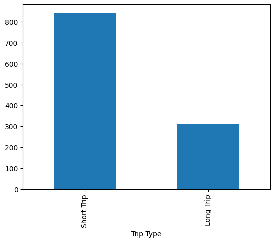

```python
uber_df["Trip Type"].value_counts().plot.bar()
```

[output not shown]

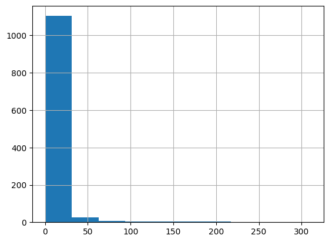

```python
uber_df["MILES*"].hist().plot()
```

### Groupby

We are going to groupby the start column and we are going to view how many rides were taken in total from that particular place.

A rule of thumb while using a groupby object is that, the groupby method should always be followed by an aggregation method. In pandas, aggregation methods are used to summarize and compute statistics on data. Some of the common aggregation methods in pandas include:

- sum()
- mean()
- median()
- min()
- max()
- count()
- std()
- var()
- summarize()
- agg()
- value_counts()
- nunique()

```python
df_group = uber_df.groupby("START*")
```

```python
df_group.count()
```

| START* | START_DATE* | END_DATE* | CATEGORY* | STOP* | MILES* | PURPOSE* | Trip Type |
| --- | --- | --- | --- | --- | --- | --- | --- |
| Agnew | 4 | 4 | 4 | 4 | 4 | 0 | 4 |
| Almond | 1 | 1 | 1 | 1 | 1 | 0 | 1 |
| Apex | 17 | 17 | 17 | 17 | 17 | 11 | 17 |
| Arabi | 1 | 1 | 1 | 1 | 1 | 1 | 1 |
| Arlington | 1 | 1 | 1 | 1 | 1 | 0 | 1 |
| ... | ... | ... | ... | ... | ... | ... | ... |
| West University | 2 | 2 | 2 | 2 | 2 | 1 | 2 |
| Weston | 2 | 2 | 2 | 2 | 2 | 1 | 2 |
| Westpark Place | 17 | 17 | 17 | 17 | 17 | 5 | 17 |
| Whitebridge | 68 | 68 | 68 | 68 | 68 | 36 | 68 |
| Winston Salem | 1 | 1 | 1 | 1 | 1 | 1 | 1 |

176 rows × 7 columns

```python
uber_df.groupby("START*")["MILES*"].agg("mean").head(n=20)
```

```
START*
Agnew                          2.775000
Almond                        15.200000
Apex                           5.341176
Arabi                         17.000000
Arlington                      4.900000
Arlington Park at Amberly      1.300000
Asheville                    143.850000
Austin                       136.000000
Banner Elk                    12.375000
Bellevue                      12.900000
Berkeley                      14.375000
Boone                        102.000000
Briar Meadow                   9.600000
Bryson City                   20.820000
Burtrose                       4.800000
CBD                            3.850000
Capitol One                    9.450000
Cary                           8.911940
Central                        1.950000
Chalmette                      1.100000
Name: MILES*, dtype: float64
```

```python
uber_df.groupby("START*")["MILES*"].agg(["mean", "max"]).head(n=20)
```

| START* | mean | max |
| --- | --- | --- |
| Agnew | 2.775000 | 4.3 |
| Almond | 15.200000 | 15.2 |
| Apex | 5.341176 | 9.0 |
| Arabi | 17.000000 | 17.0 |
| Arlington | 4.900000 | 4.9 |
| Arlington Park at Amberly | 1.300000 | 1.3 |
| Asheville | 143.850000 | 195.9 |
| Austin | 136.000000 | 136.0 |
| Banner Elk | 12.375000 | 28.1 |
| Bellevue | 12.900000 | 12.9 |
| Berkeley | 14.375000 | 47.7 |
| Boone | 102.000000 | 180.2 |
| Briar Meadow | 9.600000 | 9.6 |
| Bryson City | 20.820000 | 68.4 |
| Burtrose | 4.800000 | 4.8 |
| CBD | 3.850000 | 7.7 |
| Capitol One | 9.450000 | 14.4 |
| Cary | 8.911940 | 144.0 |
| Central | 1.950000 | 2.9 |
| Chalmette | 1.100000 | 1.1 |

```python
uber_df.groupby("START*").agg(avg_miles_covered = ("MILES*", "mean"), number_of_rides = ("MILES*", "count"), total_miles_covered = ("MILES*", "sum")).head(n=10)
```

| START* | avg_miles_covered | number_of_rides | total_miles_covered |
| --- | --- | --- | --- |
| Agnew | 2.775000 | 4 | 11.1 |
| Almond | 15.200000 | 1 | 15.2 |
| Apex | 5.341176 | 17 | 90.8 |
| Arabi | 17.000000 | 1 | 17.0 |
| Arlington | 4.900000 | 1 | 4.9 |
| Arlington Park at Amberly | 1.300000 | 1 | 1.3 |
| Asheville | 143.850000 | 2 | 287.7 |
| Austin | 136.000000 | 1 | 136.0 |
| Banner Elk | 12.375000 | 8 | 99.0 |
| Bellevue | 12.900000 | 1 | 12.9 |

```python
uber_df.groupby(["START*", "STOP*"])["MILES*"].agg(["mean", "max"]).head(n=20)
```

| START* | STOP* | mean | max |
| --- | --- | --- | --- |
| Agnew | Agnew | 2.200000 | 2.2 |
|  | Cory | 4.300000 | 4.3 |
|  | Renaissance | 2.300000 | 2.4 |
| Almond | Bryson City | 15.200000 | 15.2 |
| Apex | Apex | 2.150000 | 3.3 |
|  | Cary | 5.792308 | 8.8 |
|  | Eagle Rock | 2.200000 | 2.2 |
|  | Holly Springs | 9.000000 | 9.0 |
| Arabi | Metairie | 17.000000 | 17.0 |
| Arlington | Washington | 4.900000 | 4.9 |
| Arlington Park at Amberly | Lexington Park at Amberly | 1.300000 | 1.3 |
| Asheville | Mebane | 195.900000 | 195.9 |
|  | Topton | 91.800000 | 91.8 |
| Austin | Katy | 136.000000 | 136.0 |
| Banner Elk | Banner Elk | 6.680000 | 13.0 |
|  | Boone | 15.100000 | 15.1 |
|  | Elk Park | 22.400000 | 22.4 |
|  | Newland | 28.100000 | 28.1 |
| Bellevue | Seattle | 12.900000 | 12.9 |
| Berkeley | El Cerrito | 2.300000 | 2.3 |

### Missing values and null values

```python
uber_df.isnull()
```

|  | START_DATE* | END_DATE* | CATEGORY* | START* | STOP* | MILES* | PURPOSE* | Trip Type |
| --- | --- | --- | --- | --- | --- | --- | --- | --- |
| 0 | False | False | False | False | False | False | False | False |
| 1 | False | False | False | False | False | False | True | False |
| 2 | False | False | False | False | False | False | False | False |
| 3 | False | False | False | False | False | False | False | False |
| 4 | False | False | False | False | False | False | False | False |
| ... | ... | ... | ... | ... | ... | ... | ... | ... |
| 1149 | False | False | False | False | False | False | False | False |
| 1150 | False | False | False | False | False | False | False | False |
| 1151 | False | False | False | False | False | False | False | False |
| 1152 | False | False | False | False | False | False | False | False |
| 1153 | False | False | False | False | False | False | False | False |

1154 rows × 8 columns

```python
uber_df.isnull().sum()
```

```
START_DATE*      0
END_DATE*        0
CATEGORY*        0
START*           0
STOP*            0
MILES*           0
PURPOSE*       502
Trip Type        0
dtype: int64
```

### End of Day 2 Pandas Discussion

- To deal with null values , we can either try to analyse the columns and replace the null values with suitable column values or we can drop the records with null values. (Droping records is not the recommended method)

If the percentage of missing values in a column exceeds 70% of the total number of values in that column, it is advisable to consider dropping that column. Conversely, if the percentage of missing values is less than 10% of the total number of rows, it may be preferable to replace them with the mode (the most frequently occurring value) for categorical data or with 0/1 for numerical data.

```python
# Let's analyse the purose column

uber_df["PURPOSE*"].nunique()
```

```
10
```

```python
uber_df["PURPOSE*"].value_counts()
```

```
PURPOSE*
Meeting            187
Meal/Entertain     160
Errand/Supplies    128
Customer Visit     101
Temporary Site      49
Between Offices     18
Moving               4
Airport/Travel       3
Charity ($)          1
Commute              1
Name: count, dtype: int64
```

```python
uber_df["PURPOSE*"].fillna("Meeting")
```

```
0        Meal/Entertain
1               Meeting
2       Errand/Supplies
3               Meeting
4        Customer Visit
             ...
1149     Customer Visit
1150            Meeting
1151     Temporary Site
1152            Meeting
1153     Temporary Site
Name: PURPOSE*, Length: 1154, dtype: object
```

```python
uber_df.isna().sum()
```

```
START_DATE*      0
END_DATE*        0
CATEGORY*        0
START*           0
STOP*            0
MILES*           0
PURPOSE*       502
Trip Type        0
dtype: int64
```

- The changes did'nt took place because the "fillna" was just a view, to make the changes parmanent we have to assign the values for changes to reflect.
- There are two methods of replacing null values
1. Assigning values
2. Set the inplace parameter to true
- Note: Don't use assigning values and inplace parameter at the same time.

```python
# Method 1 - Assigning values
uber_df["PURPOSE*"] = uber_df["PURPOSE*"].fillna("Meeting")
```

```python
# Method 2 - Set the inplace parameter to true
uber_df["PURPOSE*"].fillna("Meeting",  inplace=True)
```

```python
uber_df.isna().sum()
```

```
START_DATE*    0
END_DATE*      0
CATEGORY*      0
START*         0
STOP*          0
MILES*         0
PURPOSE*       0
Trip Type      0
dtype: int64
```

- Instead of using fillna method which replaces the null values with "mode" we can use dropna method to drop the null values from the data set.

```python
uber_df.dropna()
```

|  | START_DATE* | END_DATE* | CATEGORY* | START* | STOP* | MILES* | PURPOSE* | Trip Type |
| --- | --- | --- | --- | --- | --- | --- | --- | --- |
| 0 | 2016-01-01 21:11:00 | 2016-01-01 21:17:00 | Business | Fort Pierce | Fort Pierce | 5.1 | Meal/Entertain | Short Trip |
| 1 | 2016-01-02 01:25:00 | 2016-01-02 01:37:00 | Business | Fort Pierce | Fort Pierce | 5.0 | Meeting | Short Trip |
| 2 | 2016-01-02 20:25:00 | 2016-01-02 20:38:00 | Business | Fort Pierce | Fort Pierce | 4.8 | Errand/Supplies | Short Trip |
| 3 | 2016-01-05 17:31:00 | 2016-01-05 17:45:00 | Business | Fort Pierce | Fort Pierce | 4.7 | Meeting | Short Trip |
| 4 | 2016-01-06 14:42:00 | 2016-01-06 15:49:00 | Business | Fort Pierce | West Palm Beach | 63.7 | Customer Visit | Long Trip |
| ... | ... | ... | ... | ... | ... | ... | ... | ... |
| 1149 | 2016-12-30 23:06:00 | 2016-12-30 23:10:00 | Business | Kar?chi | Kar?chi | 0.8 | Customer Visit | Short Trip |
| 1150 | 2016-12-31 01:07:00 | 2016-12-31 01:14:00 | Business | Kar?chi | Kar?chi | 0.7 | Meeting | Short Trip |
| 1151 | 2016-12-31 13:24:00 | 2016-12-31 13:42:00 | Business | Kar?chi | Unknown Location | 3.9 | Temporary Site | Short Trip |
| 1152 | 2016-12-31 15:03:00 | 2016-12-31 15:38:00 | Business | Unknown Location | Unknown Location | 16.2 | Meeting | Long Trip |
| 1153 | 2016-12-31 21:32:00 | 2016-12-31 21:50:00 | Business | Katunayake | Gampaha | 6.4 | Temporary Site | Short Trip |

1154 rows × 8 columns

Outliers - Outliers in a dataset are data points that significantly differ from the majority of the data points. In other words, they are observations that appear to be unusually distant from the central tendency of the data, such as the mean or median.

### Outlier Detection & Removal

```python
sample_data = pd.DataFrame([[150], [160], [170], [180], [185], [140], [130], [120], [190], [300]], columns = ["Height in CM"])
```

```python
sample_data
```

|  | Height in CM |
| --- | --- |
| 0 | 150 |
| 1 | 160 |
| 2 | 170 |
| 3 | 180 |
| 4 | 185 |
| 5 | 140 |
| 6 | 130 |
| 7 | 120 |
| 8 | 190 |
| 9 | 300 |

```python
sample_data.reset_index(level=0, inplace=True)
```

We are adding an index column because we wanted to visualize the scatter plot and make it more readable. In the first sample data output we can see that the table does not have a dedicated index column. The other column is just the label.

```python
sample_data
```

|  | index | Height in CM |
| --- | --- | --- |
| 0 | 0 | 150 |
| 1 | 1 | 160 |
| 2 | 2 | 170 |
| 3 | 3 | 180 |
| 4 | 4 | 185 |
| 5 | 5 | 140 |
| 6 | 6 | 130 |
| 7 | 7 | 120 |
| 8 | 8 | 190 |
| 9 | 9 | 300 |

[output not shown]

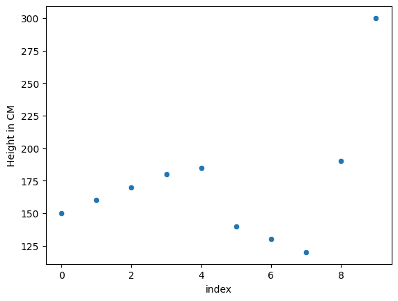

```python
import seaborn as sns
sns.scatterplot(x="index", y="Height in CM", data=sample_data)
```

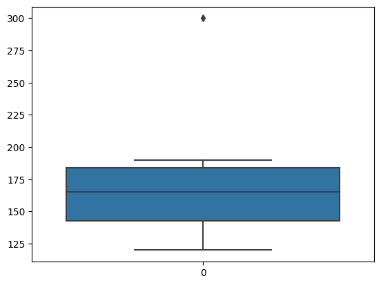

```python
# This is the plot that is used whenever we want to detect outliers.

sns.boxplot(sample_data["Height in CM"])
```

```python
def outlier_detection(datacolumn):
    sorted(datacolumn)
    Q1,Q3 = np.percentile(datacolumn , [25,75]) # Q1- first quartile value, Q3- third quartile value
    IQR = Q3 - Q1 # IQR - Inter quartile range
    lower_range = Q1 - (1.5 * IQR) # min permissible limit
    upper_range = Q3 + (1.5 * IQR) # max permissible limit
    return lower_range,upper_range
```

Q1 - (1.5 * IQR) - Help to include the values within the range 80 to 100

```python
lower, upper = outlier_detection(sample_data["Height in CM"])
```

```python
print("The lower range is", lower)
print("The upper range is", upper)
```

```
The lower range is 80.625
The upper range is 245.625
```

```python
sample_data[ (sample_data["Height in CM"] > upper) | (sample_data["Height in CM"] < lower) ]
```

|  | index | Height in CM |
| --- | --- | --- |
| 9 | 9 | 300 |

```python
sample_data.drop(sample_data[ (sample_data["Height in CM"] > upper) | (sample_data["Height in CM"] < lower) ].index , inplace=True)
```

```python
sample_data
```

|  | index | Height in CM |
| --- | --- | --- |
| 0 | 0 | 150 |
| 1 | 1 | 160 |
| 2 | 2 | 170 |
| 3 | 3 | 180 |
| 4 | 4 | 185 |
| 5 | 5 | 140 |
| 6 | 6 | 130 |
| 7 | 7 | 120 |
| 8 | 8 | 190 |

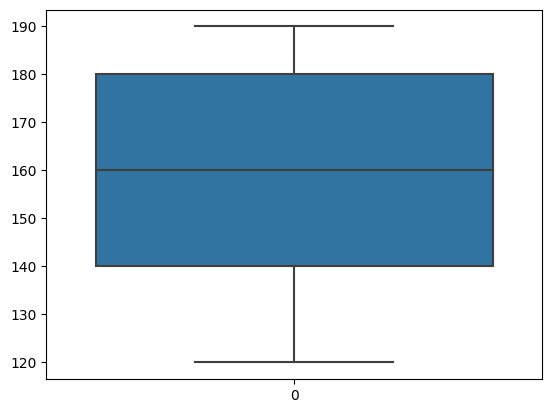

```python
sns.boxplot(sample_data["Height in CM"])
```